# Tracking common information and public announcements in Polymath.

### Patrick Allo (joint work with Bart Van Kerkhove and Jean Paul Van Bendegem)

#### Oxford Internet Institute, University of Oxford

# Case-study: The Polymath-projects

- “Massive” online collaboration in mathematics initiated by Timothy Gowers in 2009.
- Collaborative mathematical problem-solving (proving a theorem) via interaction in blog discussion-threads.
- 12 Polymath-projects started in the last 8 years.

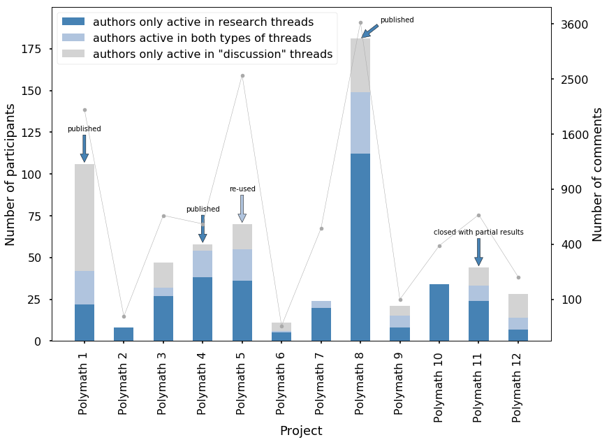

```python
plot_overview(PM_FRAME, annotate=True)
```

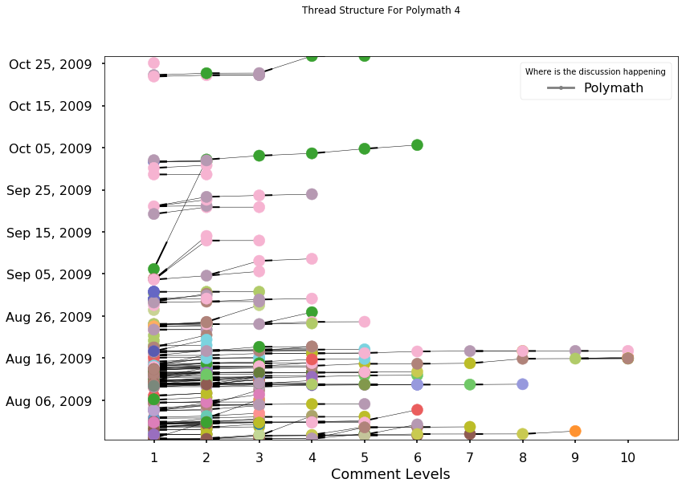

```python
plot_discussion_tree(PM_FRAME, **PM4_FOCUS)
```

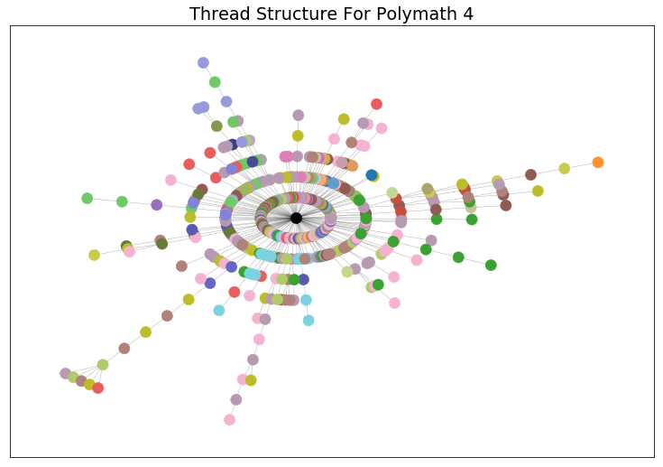

```python
plot_discussion_tree_radial(PM_FRAME, **PM4_FOCUS)
```

## Two perspectives

### Polymath as a case-study in the philosophy of mathematical practices

- Source-material to answer questions about real-life mathematical inquiry.
- Polymath as a massive repository of mathematics in action.
- Mathematics “as we know it,” but now on the front-stage.

### Polymath as a case-study in internet-research

- Example of e-research, crowd-science, and citizen-science.
- Polymath as an example of how to organise scientific collaboration online.
- A “new kind of mathematics”.

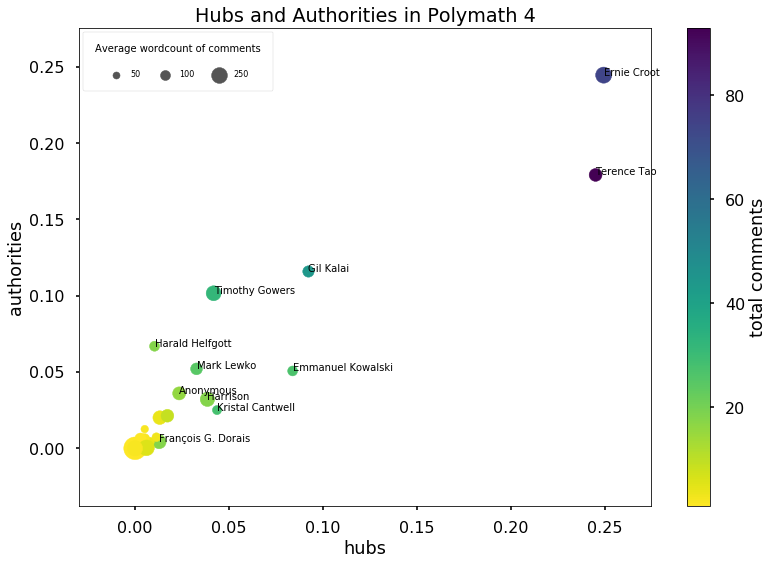

```python
plot_scatter_authors_hits(PM_FRAME, "Polymath 4", thread_type="research threads", fontsize=10)
```

### Polymath as a case-study in the philosophy of mathematical practices

- Source-material to answer questions about real-life mathematical inquiry.
- Polymath as a massive repository of mathematics in action.
- Mathematics “as we know it,” but now on the front-stage.

### Polymath as a case-study in internet-research

- Example of e-research, crowd-science, and citizen-science.
- Polymath as an example of how to organise scientific collaboration online.
- A “new kind of mathematics”.

### A methodological challenge

How do we combine both perspectives, and use insights and methods from the study of online collaboration to contribute to the philosophy of mathematical practices, and more generally to our understanding of scientific problem-solving processes?

# Today's plan

### Consider one specific methodological challenge

Explain how effective collaboration in Polymath is possible?

### Present this challenge and its resolution as a kind of abductive reasoning

- Inference to the best explanation.
- Answering “how possible” questions.
- Which ”general principles” or “theoretical insights” are needed to explain, with the available data, how succesful collaboration is possible?

### Contrast with related question of how formal models of scientific communities should acquire empirical grounding

- Problem of idealisation in simulation-models of scientific communities (Martini & Pinto, 2016).
- Explain how epistemically succesuful collaboration is possible by building on a specific data-set.

# The reasoning reconstructed (I): Successful collaboration and strong group-level attitudes

- Effective participation requires a detailed shared understanding of the problem-solving situation, because aggregation is a social/interactive process:
  - Cannot be reduced to outsourcing small tasks and aggregating the results.
  - Poorly defined epistemic tasks.
  - No hard-coded aggregation or error-correction procedure.
- Epistemic goals and epistemic standards are more diverse:
  - Increased efficiency is not the only goal of collaborative proving.
  - Showing mathematics is action is an explicit goal.
  - Improving and reflecting on the process is part of the projects.
- Additional features we associate with scientific communities:
  - No strict separation between leaders and participants.
  - Research-agenda is also crowd-sourced.

### What makes collaboration possible?

- Permanent and publicly accessible repository of contributions.
- Regular summaries, and in some cases wiki-based knowledge-base.
- Small contributions rule to avoid unncecessary creation of information-asymmetries:
  - Keep contributions small.
  - Share ideas quickly.

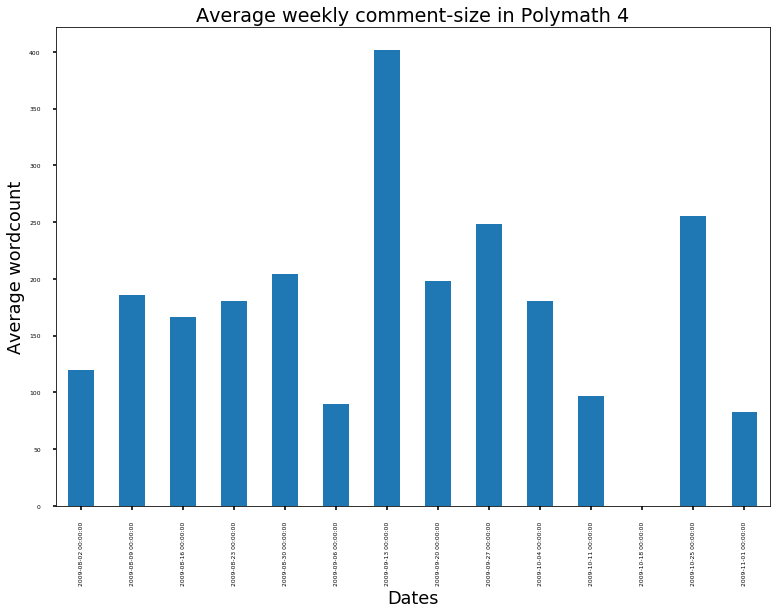

```python
plot_comment_sizes(PM_FRAME, **PM4_FOCUS, resample="weekly")
```

### Insights from “logics for teamwork”

Source: Dunin-Keplicz, B., & Verbrugge, R. (2010). Wiley Series in Agent Technology: Teamwork in multi-agent systems. A formal approach. Chichester: Wiley.

- Role of group-level attitudes
- General, mutual, and collective intentions.
- Collective intentions require **common belief of mutual intentions**.
- This is much harder to study and keep track of!

# The reasoning reconstructed (II): Common beliefs are possible because interactions take place in informationally transparent shared contexts.

## First problem

- Common beliefs require reliable communication (no uncertainty about message and about receipt of message).
- But: asynchronous communication is a text-book example of *un*reliable communication.
- And: merely claiming that access is universal isn't enough.  
  (Everybody *can* read, but who *does* read?)

## Second problem

- Common belief within *G* requires public announcement to all members of *G*.
- But: strict interaction-patterns only reveal one-to-one communication.

## Diagnosis: information-flow isn't limited to direct interactions

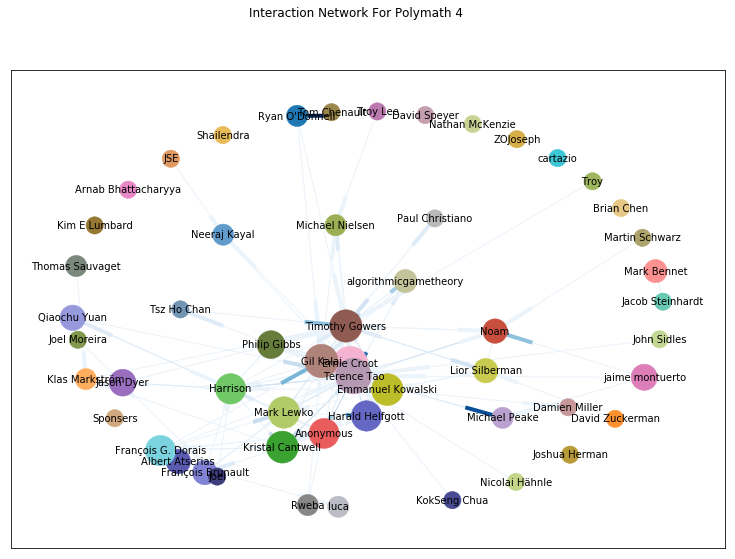

```python
draw_network(PM_FRAME, project="Polymath 4", thread_type="research threads", stage=-1, fontsize=10)
```

## Proposed solution: information-flow based on joint affiliation to some event

- Affiliation-networks relate individuals to something else (events, places, interests).
- Can be used to construct a network based on common affiliation.
- Use affiliation to certain *communicative events* or *contexts* to model co-presence.
- Treat co-presence as a sufficient condition to make public-announcements.
- Side-note: co-presence is not a binary relation, but is easier to display as if it were binary (as direct interaction).
- But which events or contexts?

## Developing the solution: the centre of discussion

- “Centre of discussion” as a metaphor for the dynamic context in which participants interact.
- Intended to capture idea that joint presence is epistemically transparent.

### Dynamics

- Contributing instantly puts one in the centre of discussion.
- Moving out of the centre of discussion happens gradually.

[figure not shown]

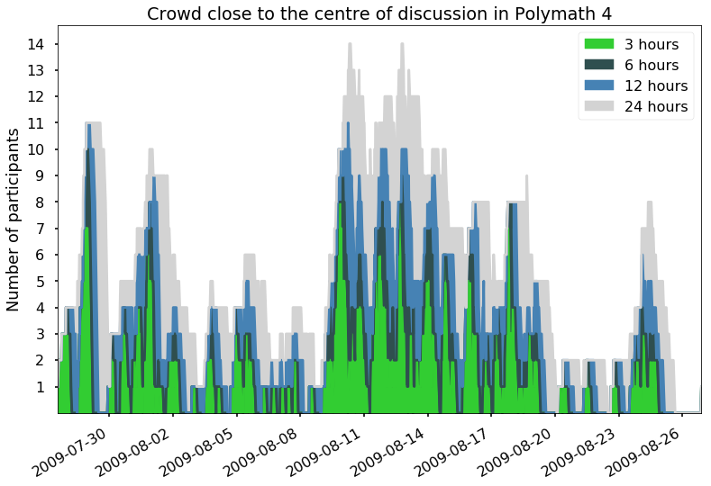

```python
plot_centre_crowd(PM_FRAME, "Polymath 4", stage=2, thread_type="research threads")
```

### Epistemologically

- Closeness to the centre of discussion signals presence in the centre of discussion, and
- is sufficient to know who is also close.

# Justification: from epistemic transparency to common information

## Outline of the argument

- Shared understanding needed for successful collaboration requires common information (knowledge or belief).
- Common information can only be established and extended by making public announcements (no uncertainty about the effect of an announcement within a given group).
- Common information of who is present is necessary and sufficient for making public announcements.
- Ability to know who is also close is sufficient for common knowledge of who's close.

## Transparency of closeness to the centre of discussion

- **(TC)** $\mathrm{Close}_i \to (\mathrm{Close}_j \to \mathsf{K}_i \mathrm{Close}_j)$
- If **(TC)** is an axiom-scheme (or is common knowledge) we can prove $\bigwedge_{i \in G} \mathrm{Close}_i \to \mathsf{C}_G \bigwedge_{i \in G} \mathrm{Close}_i$

[figure not shown]

# Transparency of centre of discussion

- $\mathrm{Close}_i \to (\mathrm{Close}_j \to \mathsf{K}_i \mathrm{Close}_j)$ is sufficient to prove $\bigwedge_{i \in G} \mathrm{Close}_i \to \mathsf{C}_G \bigwedge_{i \in G} \mathrm{Close}_i$,
- but is also susceptible to *imprecise knowledge*-style counterexamples.

# Weakening the requirements, and reducing the imprecision

## Teamwork based on less demanding group-information

- Insight from logics of teamwork: common-belief requirement for common intention can be weakened to match the degree of joint awareness needed in a given context, and for a particular task.

## Closeness and episodes of intense interaction

- We already moved from threads as trees to threads as events, now wz look at a thread as a series of episodes.
- Episodes of intense interaction can be identified through clustering, and participants can be *affiliated* to events.

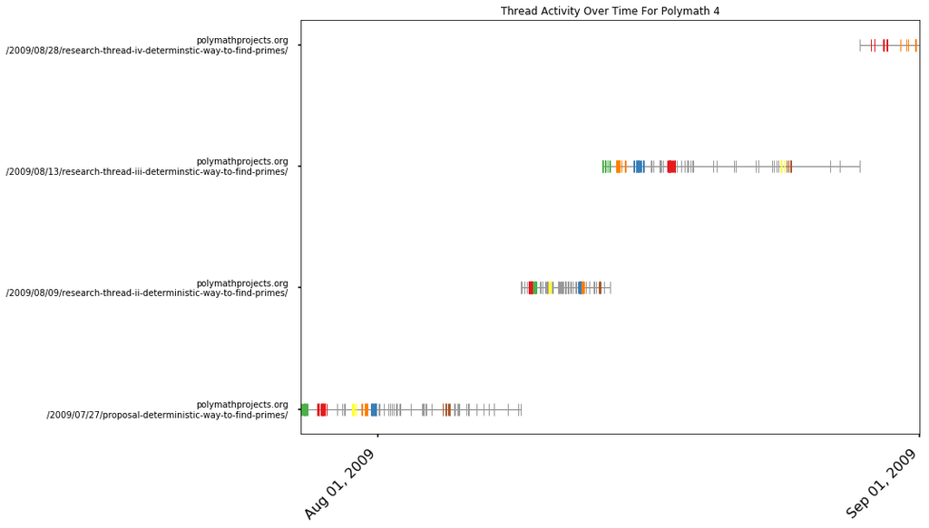

```python
plot_activity_thread(PM_FRAME, "Polymath 4", stage=3, thread_type="all threads", last="2009-09-01")
```

## Visualising co-presence

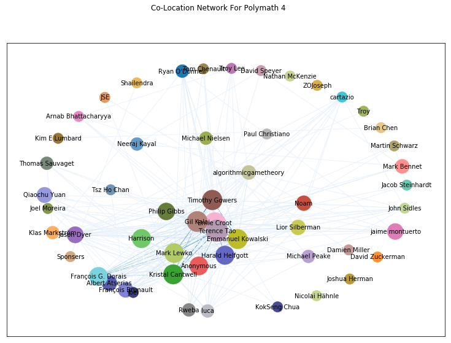

```python
draw_network(PM_FRAME, project="Polymath 4", thread_type="research threads", stage=-1, graph_type="cluster", fontsize=10)
```

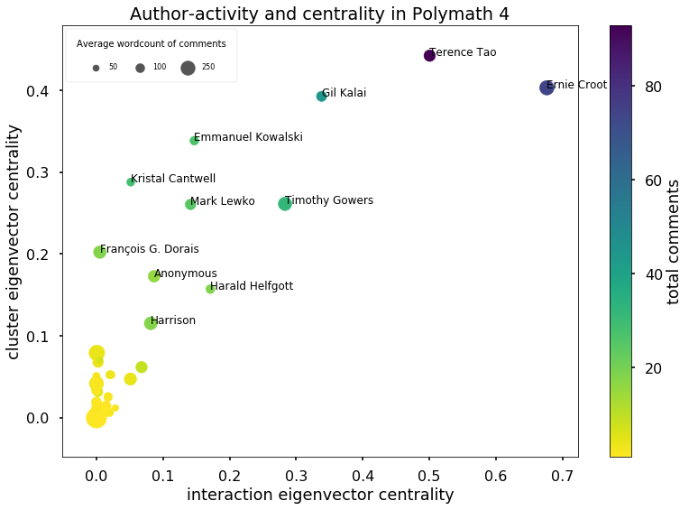

```python
plot_scatter_authors(PM_FRAME, project="Polymath 4", thread_type="research threads", stage=-1,
                     measure="eigenvector centrality",
                     weight={"interaction": 'weight',"cluster": 'weight'},
                    to_undirected=False)
```

## Episodes, closeness, and public announcements

- Episodes or clusters of intense interaction provide the context needed to decide what counts as *close* to the centre of discussion.
- This “threshold” is not knowable in the sense of **TC**, but is accessible to us.
- **Modelling assumption 1:** every participant to an episode is *close* between joining and the end of the episode.
- **Modelling assumption 2:** all comments in a given episode are public announcements within the group of participants that are close at the end of that episode.
- The network obtained from the affiliations to episodes is the sum of the equivalence-classes corresponding to groups within which it is at some point common knowledge that they are all close.
- We can model a comment $c$ as a public-announcement by associating the episode $e$ it is part of with the announcement-type that treats the content of $c$ as public to all participants that are close during $e$, and uncertain for all other participants.

# Concluding remarks: How is successful collaboration possible?

- Everything is accessible,
- high-level summaries are provided at regular intervals,
- the small-contribution rule prevents the creation of informational asymmetries,
- intense episodes of interaction create the right kind of context for keeping track, as a group, of the problem-solving context.